# Homework 2

Here is Rhys Long’s submission for Homework 2

Rhys Long (University of Massachusetts Amherst)  
03-14-2022

```r
library("alr4")
library("ggplot2")
library("smss")
library("tidyverse")
library("numbers")
```

## Question 1

For the first question, the predictor variable is pddgdp and the response variable is fertility because the amount of fertility is influenced by the amount of ppgdp.

```r
data(UN11)
head(UN11)
```

```
                region  group fertility   ppgdp lifeExpF pctUrban
Afghanistan       Asia  other     5.968   499.0    49.49       23
Albania         Europe  other     1.525  3677.2    80.40       53
Algeria         Africa africa     2.142  4473.0    75.00       67
Angola          Africa africa     5.135  4321.9    53.17       59
Anguilla     Caribbean  other     2.000 13750.1    81.10      100
Argentina   Latin Amer  other     2.172  9162.1    79.89       93
```

When placing ppgdp on the x axis and fertility on the y axis, the correlation is negative. In other words, as the amount of ppgdp increases, the amount of fertility decreases. In the scatter plot below, a straight line mean function does not appear to be plausible for summarizing the data because the points appear to form a curve.

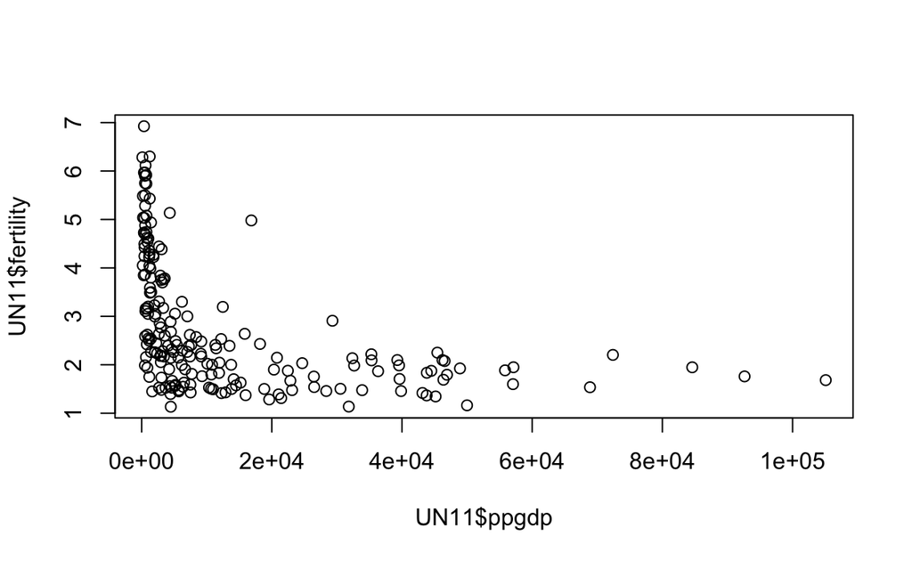

```r
plot(x=UN11$ppgdp,y=UN11$fertility)
```

When using the log() function for the predictor and response variables, there is still a negative correlation between ppgdp and fertility. However, unlike the plot without the log() function, a simple linear regression is appropriate for the corresponding scatter plot because the points are distributed in a more linear manner.

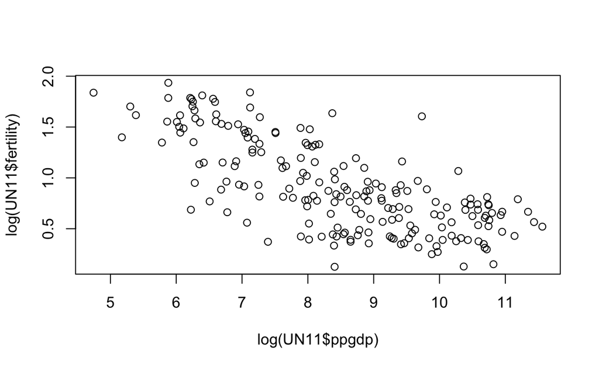

```r
plot(x=log(UN11$ppgdp),y=log(UN11$fertility))
```

## Question 2

If annual income is an explanatory variable and the response variable is expressed in terms of currency, the slope of the prediction equation wouldn’t change at all because both the rise and the run would be converted to pounds in this scenario.

```r
#Slope When The Income, X, Is In Dollars And Y Is Also Currency
Dollar_Rise=500
Dollar_Run=2500
Dollar_Slope=Dollar_Rise/Dollar_Run
c("Slope When Income Is In Dollars", Dollar_Slope)
```

```
[1] "Slope When Income Is In Dollars"
[2] "0.2"
```

```r
#Slope When The Income, X, Is In Pounds And Y Is Also Currency
Pound_Rise=Dollar_Rise/1.33
Pound_Run=Dollar_Run/1.33
Pound_Slope=Pound_Rise/Pound_Run
c("Slope When Income Is In Pounds", Pound_Slope)
```

```
[1] "Slope When Income Is In Pounds" "0.2"
```

If the response variable is not expressed in terms of currency, I hypothesize that “New Slope”=“Rise Of Old Slope”/(“Run Of Old Slope”/1.33). My hypothesis differs from the hypothesis provided in the textbook. In the book, the hypothesis is “New Slope”=“Old Slope”/1.33. To determine which hypothesis is more accurate, I will first come up with my own data set using vectors and the data.frame() function.

```r
Income_Dollars <- c(100000, 2800, 52000, 840, 590000, 3400, 2700, 430)
Response_Variable <- c(200, 23400, 7600, 864000, 520, 64200, 4920, 658300)
Data_In_Dollars <- data.frame(Income_Dollars, Response_Variable)
Data_In_Dollars
```

```
  Income_Dollars Response_Variable
1         100000               200
2           2800             23400
3          52000              7600
4            840            864000
5         590000               520
6           3400             64200
7           2700              4920
8            430            658300
```

After creating a data set with the income in dollars, I will now use the lm() function to figure out the slope and y intercept. The y intercept is listed under “(Intercept)” and the slope is listed under “Income_Dollars”.

```r
Dollar_Regression <- lm(formula = Response_Variable~Income_Dollars, data=Data_In_Dollars)
print(Dollar_Regression)
```

```
Call:
lm(formula = Response_Variable ~ Income_Dollars, data = Data_In_Dollars)

Coefficients:
   (Intercept)  Income_Dollars
    251694.004          -0.519
```

Before testing the hypotheses, I will now create a Data_In_Pounds data set, which has the same response values as Data_In_Dollars, but has the income values converted to pounds. I will also use lm() to determine what the actual slope would be if the income is converted to pounds.

```r
Data_In_Pounds <- rename(Data_In_Dollars, Income_Pounds=Income_Dollars) %>%
  mutate(Income_Pounds=Income_Pounds/1.33)
Data_In_Pounds
```

```
  Income_Pounds Response_Variable
1    75187.9699               200
2     2105.2632             23400
3    39097.7444              7600
4      631.5789            864000
5   443609.0226               520
6     2556.3910             64200
7     2030.0752              4920
8      323.3083            658300
```

```r
Pound_Regression <- lm(formula = Response_Variable~Income_Pounds, data=Data_In_Pounds)
print(Pound_Regression)
```

```
Call:
lm(formula = Response_Variable ~ Income_Pounds, data = Data_In_Pounds)

Coefficients:
  (Intercept)  Income_Pounds
    2.517e+05     -6.903e-01
```

Now, I will test the book’s hypothesis and my hypothesis to see which one is more accurate. The equation I’m using to test the book’s hypothesis is M2=M1/1.33 and the equation I’m using to test my hypothesis is M2=(Y-B)/(X2). In both equations, M1 is the slope of the data when the income is in dollars and M2 is the predicted slope when the income is converted to pounds. In my equation, X1 is the “run value” of M1, X2 is the predicted “run value” of M2, Y1 and Y2 are 0, B1 is the y intercept of the prediction equation when income is in dollars, and B2 is the y intercept of the of the prediction equation when income is in pounds (and is identical to B1).

```r
#The Book's Hypothesis
M1=-0.519
Book_M2=M1/1.33

#My Hypothesis
Y1=0
B1=251694.004
X1=(Y1-B1)/M1
Y2=Y1
B2=B1
X2=X1/1.33
Rhys_M2=(Y2-B2)/(X2)

#The Actual Answer
Actual_M2=-6.903e-1
```

Based on the results below, it is safe to conclude that if income is converted to pounds, the new slope would have the same rise value as the old slope, but the run value would be different. It is also safe to conclude that converting the income to pounds will not change the correlation of the data because the slope would still negative and a negative slope is indicative of a negative correlation.

```r
#Comparing Slopes
c("Book's Predicted Slope", Book_M2)
```

```
[1] "Book's Predicted Slope" "-0.390225563909774"
```

```r
c("My Predicted Slope", Rhys_M2)
```

```
[1] "My Predicted Slope" "-0.69027"
```

```r
c("Actual Slope", Actual_M2)
```

```
[1] "Actual Slope" "-0.6903"
```

## Question 3

Based on the scatter plot matrix below it is definitely safe to conclude that the runoff volumes of similar venues are correlated with each other. More specifically, the runoff volumes of APMAM, APSAB, and APSLAKE are all positively correlated with each other and the runoff volumes of OPBPC, OPRC, and OPSLAKE are all positively correlated with each other. It is also possible to conclude that the runoff volume of BSAAM is correlated with the runoff volumes of OPBPC, OPRC, and OPSLAKE, but not with the runoff volumes of APMAM, APSAB, and APSLAKE. However, it isn’t possible to conclude whether the runoff volumes of future years can be predicted because even though there appears to be a very slight positive correlation with year and runoff volumes for each venue, the correlations look too weak to be significant.

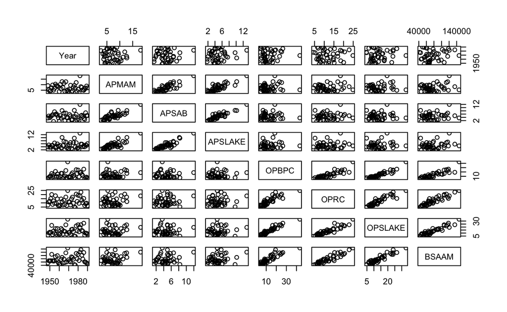

```r
data(water)
pairs(water)
```

## Question 4

To find the relationships between the quality, helpfulness, clarity, easiness of instructor’s courses, and rater interest, I can’t just use the pairs(Rateprof) function because when I do, I won’t get an scatter plot that contains the variables I’m interested in analyzing.

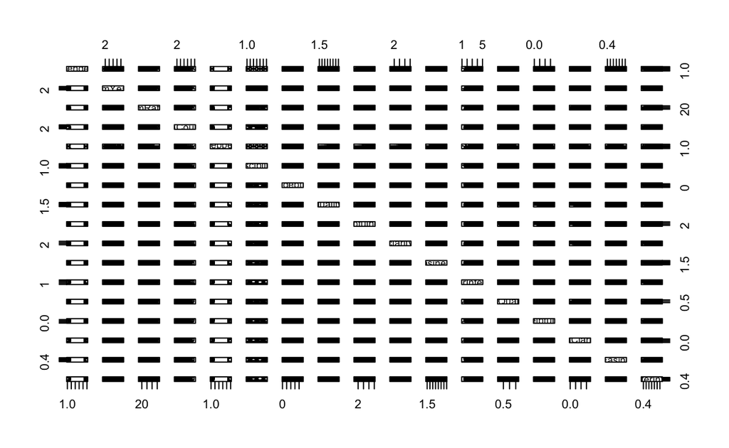

```r
data(Rateprof)
pairs(Rateprof)
```

In order to fix the problems shown in the scatter plot above, I will now create a new data set with only the quality, helpfulness, clarity, easiness of instructor’s course, and rater interest variables selected before using the pairs() function to form a scatter plot matrix.

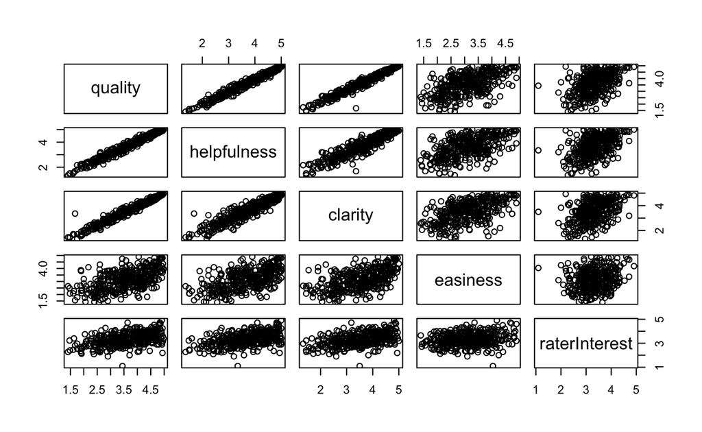

```r
Rateprof_Data <- select(Rateprof, quality:raterInterest)
pairs(Rateprof_Data)
```

Based on the scatter plot above, quality ratings have a strong positive correlation with helpfulness and clarity ratings. In other words, if a professor received high quality ratings, chances are that they received high helpfulness and clarity ratings as well. There is also a strong positive correlation between helpfulness and clarity, but the correlation isn’t as strong as the first two correlations I mentioned. The correlation between easiness and quality, easiness and helpfulness, and clarity and easiness are also positive, but the correlations are somewhat weak. Out of the possible correlations depicted in the scatterplot, the correlations containing the “raterInterest” variable are the weakest, meaning that a rater’s interest in the subject matter doesn’t influence how they rate their professor.

## Question 5

# Part 1: Analyzing The Correlation Between Frequency of Religious Service Attendance and Political Ideology

Since the religiosity and political ideology are both categorical variables, I will first provide bar charts depicting which political ideology and religiosity choices were most common in the survey.

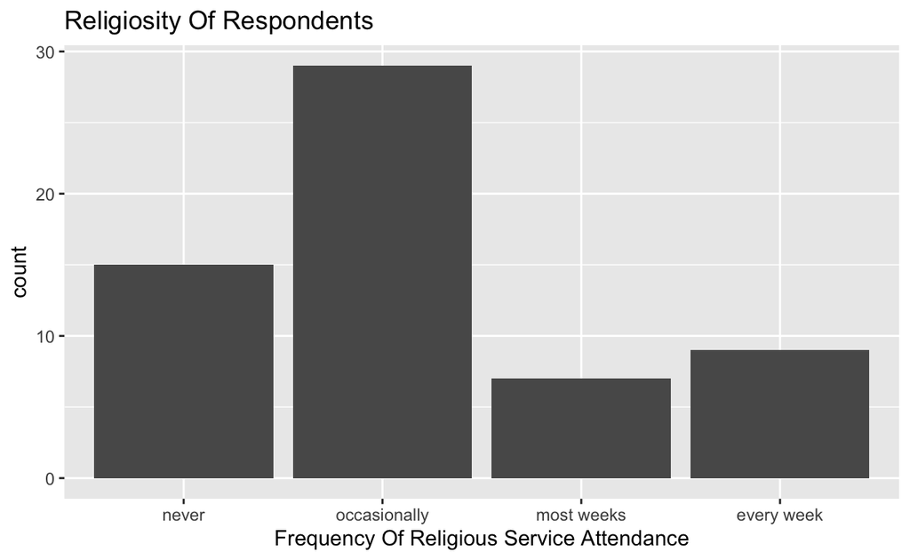

```r
#Data Set
data("student.survey")
ggplot(student.survey, aes(x=re)) + geom_bar() + labs(title="Religiosity Of Respondents", x="Frequency Of Religious Service Attendance")
```

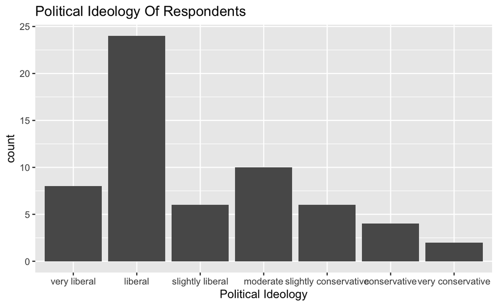

```r
ggplot(student.survey, aes(x=pi)) + geom_bar() + labs(title="Political Ideology Of Respondents", x="Political Ideology")
```

```r
Converted_Survey <- select(student.survey, re, pi) %>%
  mutate(re=case_when(
    re=="never"~0,
    re=="occasionally"~1,
    re=="most weeks"~2,
    re=="every week"~3,
    )) %>%
  mutate(pi=case_when(
    pi=="very liberal"~-3,
    pi=="liberal"~-2,
    pi=="slightly liberal"~-1,
    pi=="moderate"~0,
    pi=="slightly conservative"~1,
    pi=="conservative"~2,
    pi=="very conservative"~3,
  ))
Converted_Survey
```

```
   re pi
1   2  2
2   1 -2
3   2 -2
4   1  0
5   0 -3
6   1 -2
7   1 -2
8   1 -2
9   1 -3
10  0 -1
11  1  1
12  1 -2
13  1 -3
14  1  0
```

[output cut: 46 more lines]

```r
summary(Converted_Survey, re, pi)
```

```
       re             pi
 Min.   :0.00   Min.   :-3.000
 1st Qu.:0.75   1st Qu.:-2.000
 Median :1.00   Median :-2.000
 Mean   :1.17   Mean   :-0.967
 3rd Qu.:2.00   3rd Qu.: 0.000
 Max.   :3.00   Max.   : 3.000
```

Now, I will use regressions to figure out how correlated religious service attendance frequency is with political ideology. Given that religious service attendance frequency could be responsible for shaping political ideologies and politics may be responsible for turning people towards or away from religion, I am going to create two scatter plots with 2 separate regression equations. In the first scatter plot, religious service attendance frequency is the explanatory variable and political ideology is the response variable. In the second scatter plot, the vice versa is true.

```r
Scenario_1 <- lm(formula = pi~re, data=Converted_Survey)
print(Scenario_1)
```

```
Call:
lm(formula = pi ~ re, data = Converted_Survey)

Coefficients:
(Intercept)           re
    -2.0988       0.9704
```

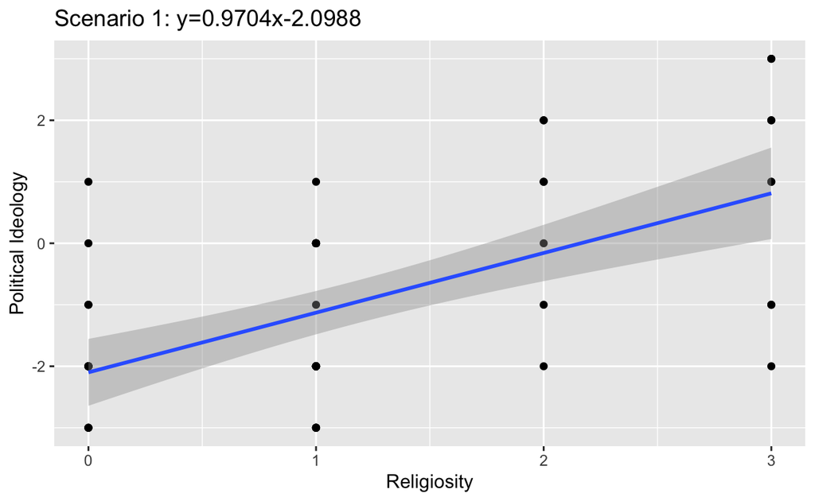

```r
ggplot(Converted_Survey, aes(x=re, y=pi)) +  geom_point() + geom_smooth(method="lm") + labs(title = "Scenario 1: y=0.9704x-2.0988", x="Religiosity", y="Political Ideology")
```

```r
Scenario_2 <- lm(formula = re~pi, data=Converted_Survey)
print(Scenario_2)
```

```
Call:
lm(formula = re ~ pi, data = Converted_Survey)

Coefficients:
(Intercept)           pi
     1.5013       0.3461
```

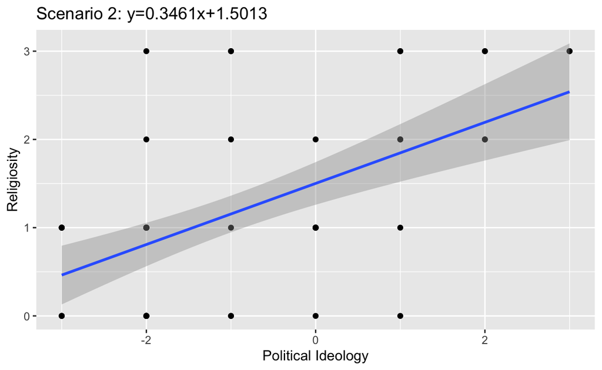

```r
ggplot(Converted_Survey, aes(x=pi, y=re)) +  geom_point() + geom_smooth(method="lm") + labs(title = "Scenario 2: y=0.3461x+1.5013", x="Political Ideology", y="Religiosity")
```

Based on the scatter plots above, it is safe to assume that being conservative is positively correlated with frequent religious service attendance and frequent religious service attendance is positively correlated with being conservative.

# Part II: Analyzing The Correlation Between Time Spent Watching TV and High School GPA.

Given that GPA and time spent watching TV are both quantitative variables, I will start off by displaying the GPA and TV time data as histograms.

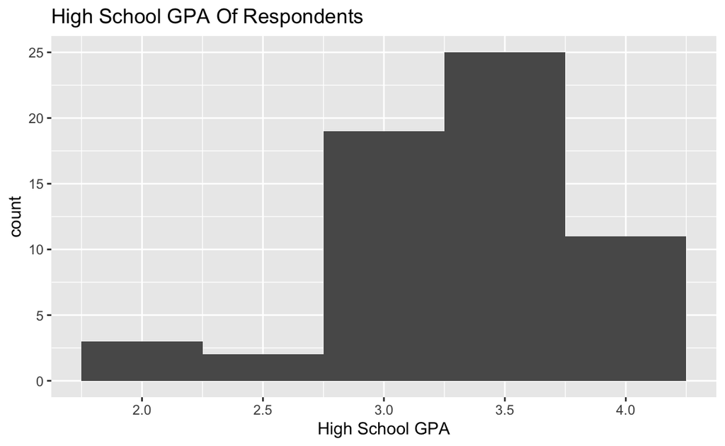

```r
ggplot(student.survey, aes(x=hi)) + geom_histogram(bins=5) + labs(title="High School GPA Of Respondents", x="High School GPA")
```

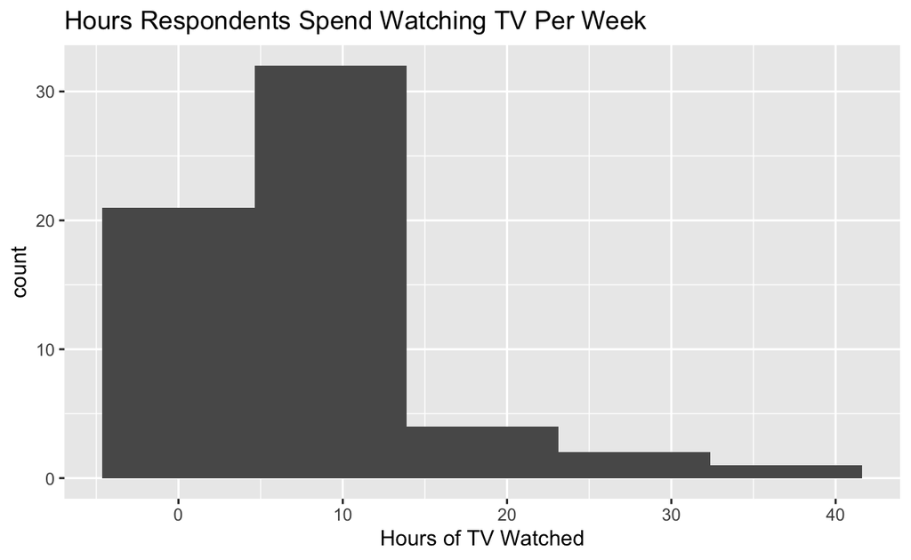

```r
ggplot(student.survey, aes(x=tv)) + geom_histogram(bins=5) + labs(title="Hours Respondents Spend Watching TV Per Week", x="Hours of TV Watched")
```

I suspect that hours spent watching TV per week is negatively correlated with high school GPA because the high school GPA histogram is skewed to the left and the TV time histogram is skewed to the right. I also suspect that both variables contain outliers because GPAs below 3.0 are uncommon and the amount of students who watch less than 10 hours of TV per week far outweighs the amount of students who watch more than 10 hours of TV per week. Before figuring out whether there are outliers, I must figure out the first quartile value for high school GPA, the third quartile value for hours spent watching TV, and the innerquartile ranges for botth variables

```r
select(student.survey, hi, tv) %>%
  summary()
```

```
       hi              tv
 Min.   :2.000   Min.   : 0.000
 1st Qu.:3.000   1st Qu.: 3.000
 Median :3.350   Median : 6.000
 Mean   :3.308   Mean   : 7.267
 3rd Qu.:3.625   3rd Qu.:10.000
 Max.   :4.000   Max.   :37.000
```

```r
summarize(student.survey, IQR(hi), IQR(tv))
```

```
  IQR(hi) IQR(tv)
1   0.625       7
```

Now that I know the inner quartile range and quartile values for both variables, I can now determine whether there are outliers.

```r
TV_IQR=7
TV_Q3=10
Upper_TV_Outlier=TV_Q3+(TV_IQR*1.5)
c("TV Time Outlier:", Upper_TV_Outlier)
```

```
[1] "TV Time Outlier:" "20.5"
```

```r
HI_IQR=0.625
HI_Q1=3
Lower_HI_Outlier=HI_Q1-(HI_IQR*1.5)
c("High School GPA Outlier:", Lower_HI_Outlier)
```

```
[1] "High School GPA Outlier:" "2.0625"
```

```r
No_Outliers <- select(student.survey, tv, hi) %>%
  filter(tv <= 20.5) %>%
  filter(hi >= 2.0625)
```

Even with the outliers removed, the high school GPA data remains skewed to the left and the TV data remains skewed to the right. According to the central tendency data below, the median GPA is still higher than the mean GPA and the median amount of TV time remains lower than the mean amount of TV time.

```r
select(student.survey, hi, tv) %>%
  summary()
```

```
       hi              tv
 Min.   :2.000   Min.   : 0.000
 1st Qu.:3.000   1st Qu.: 3.000
 Median :3.350   Median : 6.000
 Mean   :3.308   Mean   : 7.267
 3rd Qu.:3.625   3rd Qu.:10.000
 Max.   :4.000   Max.   :37.000
```

```r
select(No_Outliers, hi, tv)%>%
  summary()
```

```
       hi              tv
 Min.   :2.100   Min.   : 0.00
 1st Qu.:3.000   1st Qu.: 2.75
 Median :3.400   Median : 5.50
 Mean   :3.352   Mean   : 6.00
 3rd Qu.:3.700   3rd Qu.: 8.50
 Max.   :4.000   Max.   :16.00
```

Given that the data remains skewed with and without outliers, I suspect that TV time and High School GPA are negatively correlated. In other words, I suspect that students who spend more time watching TV have lower grades than students who spend less time watching TV. To test whether my hypothesis is true, I will create two scatter plots. One of the scatter plots will be based on the data set that includes outliers and the other regression will be based on the data without outliers. Both scatter plots will have TV time as the explanatory variable and GPA as the response variable because it is a lot more probable that watching too much TV causes bad grades.

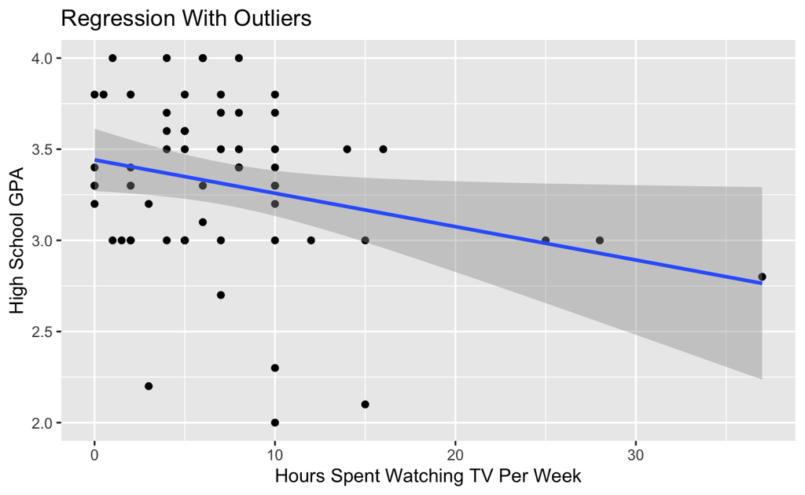

```r
ggplot(student.survey, aes(x=tv, y=hi)) + geom_point() + geom_smooth(method="lm") + labs(title="Regression With Outliers", x="Hours Spent Watching TV Per Week", y="High School GPA")
```

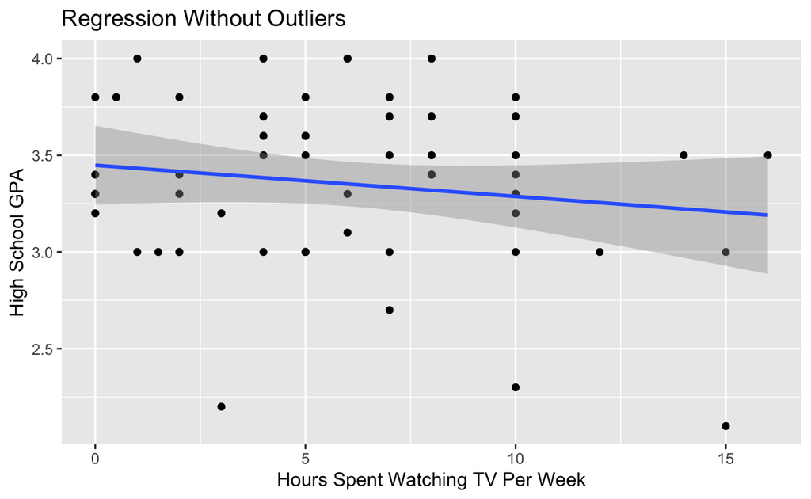

```r
ggplot(No_Outliers, aes(x=tv, y=hi)) + geom_point() + geom_smooth(method="lm") + labs(title="Regression Without Outliers", x="Hours Spent Watching TV Per Week", y="High School GPA")
```

As shown in the scatter plots above, the correlation between TV time and GPA being negative regardless of whether outliers are present or not. Visually, it appears that excluding outliers makes the correlation a lot weaker. However, the visual differences are misleading because the slope and y intercept of the data without outliers aren’t significantly different from the slope and y intercept of the data with outliers.

```r
Full_Data_Regression <- lm(formula=hi~tv, data=student.survey)
print(Full_Data_Regression)
```

```
Call:
lm(formula = hi ~ tv, data = student.survey)

Coefficients:
(Intercept)           tv
    3.44135     -0.01831
```

```r
No_Outlier_Regression <- lm(formula=hi~tv, data=No_Outliers)
print(No_Outlier_Regression)
```

```
Call:
lm(formula = hi ~ tv, data = No_Outliers)

Coefficients:
(Intercept)           tv
    3.44853     -0.01612
```

## Question 6

There is not sufficient evidence to conclude that the tutoring program was successful because according to the concept of regression to the mean, if you do well on one test, you won’t do as well on the next test and at the end of the day, the overall average of test scores will remain the same. Even if this isn’t entirely true, there are spurrious variables that are not being considered such as whether each student studied beforehand. I also determined that the control group got a 72.22 average on the first test and a 71.11 average on the second test using the code below.

```r
#First Test Everyone
Everyone_T1_Mean=70
Everyone_T1_Total=Everyone_T1_Mean*100
#First Test Treatment Group
Treatment_T1_Mean=50
Treatment_T1_Total=Treatment_T1_Mean*10
#First Test Control Group
Control_T1_Total=Everyone_T1_Total-Treatment_T1_Total
Control_T1_Mean=Control_T1_Total/90
Control_T1_Mean
```

```
[1] 72.22222
```

```r
#Second Test Everyone
Everyone_T2_Mean=70
Everyone_T2_Total=Everyone_T2_Mean*100
#Second Test Treatment Group
Treatment_T2_Mean=60
Treatment_T2_Total=Treatment_T2_Mean*10
#Second Test Control Group
Control_T2_Total=Everyone_T2_Total-Treatment_T2_Total
Control_T2_Mean=Control_T2_Total/90
Control_T2_Mean
```

```
[1] 71.11111
```